# Light pollution model

# 1. Cel projektu

Celem projektu było utworzenie modelu, który na podstawie danych satelitarnych oszacuje, jak jasne jest niebo w danym miejscu.

# 2. Generowanie danych

Dane zostały zebrane bezpośrednio przez nas ze strony http://www.lightpollutionmap.info Na podstawie pomiarów mierzonych z powierzchni Ziemi dedykowanym miernikiem SQM(L) Sky Quality Meter wysyłaliśmy zapytania do serwera dla obszarów 1, 2, 5, 10, 20, 50 oraz 100 km. Otrzymane dane w postaci JSON przetwarzaliśmy do formatu CSV. Pomiary VIIRS ze źródła http://ngdc.noaa.gov/eog/viirs/download_monthly.html są generowane przez Earth Observations Group (EOG) zawierają miesięczną średnią radiancję generowaną w postaci pliku TIFF przy użyciu Visible Infrared Imaging Radiometer Suite (VIIRS) Day/Night Band (DNB).

# 3. Dane surowe

To dane w postaci pomiarów SQM [mag/arcsec^2] oraz dane dotyczace długości, szerokości geograficznej, daty i czasu pomiaru, nazwy zawierającej lokalizację oraz użytkownika. Ponadto dane zebrane z satelity w postaci całkowitej liczby pixeli w zdjęciu, sumy wartości, średniej, odchylenia standardowego, wartości minimalnej oraz maksymalnej.

# 4. Dane poprawne technicznie

Wartość SQM zamieniona na radiancję emitowanej mocy przypadającej na jednostke powierzchni na jednostkę kąta bryłowego [W/cm^2*sr], przyjmująca wartości nieujemne.

# 5. Czyszczenie danych

Czyszczenie danych odbywało się po przez dobór pomiarów wykonanych miernikiem SQM-L, zawierającym soczewki w przeciwieństwie do miernika SQM. Braliśmy pod uwagę pomiary o wartościach SQM mniejszych od 40. Uwzględnialismy rownież takie parametry jak wysokość Księżyca i Słońca nad horyzontem, rozświetlona część księżyca (faza) oraz ilość światła dochodzącego do Ziemi od Księżyca.

```r
lp_data = read.csv('lp/db.csv', sep=';', dec='.', header=TRUE, stringsAsFactors = TRUE, encoding = "UTF-8")
lp_data$sqm = 10.8 * 10^8 * 10 ^(- 0.4 *(lp_data$sqm))
lp_data$time = as.POSIXct(lp_data$timemeasure, format="%Y-%m-%dT%H:%M:%S", tz="UTC")
lp_data$moon_frac = moonAngle(lp_data$time, lp_data$lon, lp_data$lat)$illuminatedFraction
lp_data$moon_alt = moonAngle(lp_data$time, lp_data$lon, lp_data$lat)$altitude + 90
lp_data$moon_frac_moon_alt = lp_data$moon_frac*lp_data$moon_alt
lp_data$sun_alt = sunAngle(lp_data$time, lp_data$lon, lp_data$lat)$altitude + 90
lp_data = lp_data[lp_data$time > "2015-01-01", ]
lp_data = lp_data[lp_data$sqm_l == 1,]
lp_data = lp_data[lp_data$sqm < 40,]
#lp_data = lp_data[lp_data$viirs_2015_5_mean < 40,]
#lp_data = lp_data[with(lp_data, grepl("Guzik", lp_data$name)),]
```

# 6. Analiza danych

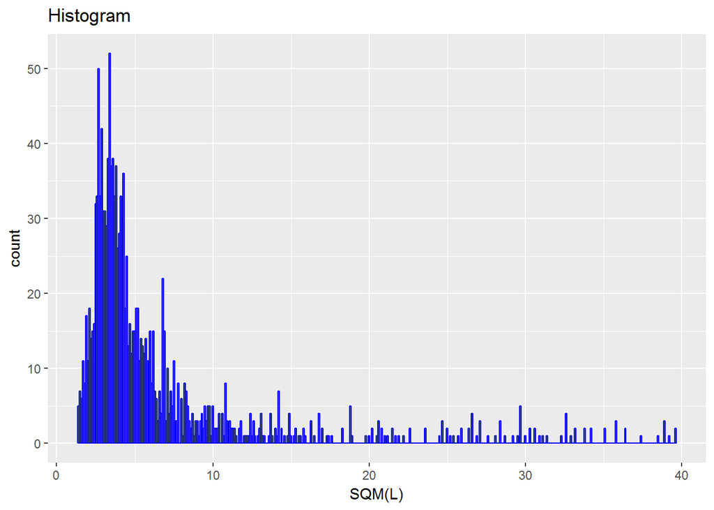

```r
#ylabel = "SQM(L) [mag/arcsec^2]"
ylabel = "[SQM(L) 10^-9W/cm^2*sr]"
ggplot(lp_data, aes(x=sqm)) + xlab("SQM(L)") + geom_histogram(binwidth=0.1, col='blue') + labs(title="Histogram")
```

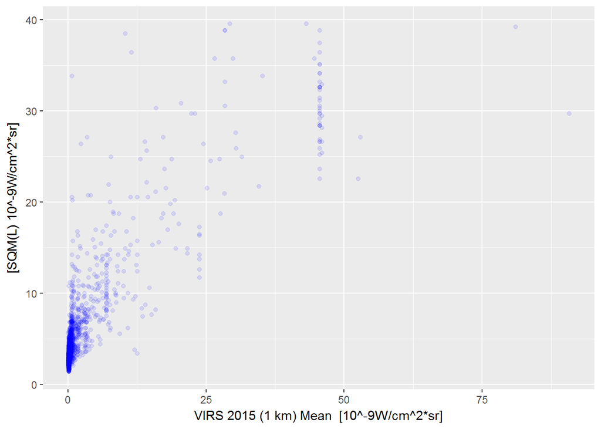

```r
## VIRS(sqm) for 1, 2, 5, 10, 20, 50, 100 [km]
ggplot(lp_data, aes(y=sqm, x=viirs_2015_1_mean)) + ylab(ylabel) + xlab("VIRS 2015 (1 km) Mean  [10^-9W/cm^2*sr]") + geom_point(color="blue", alpha=0.1)
```

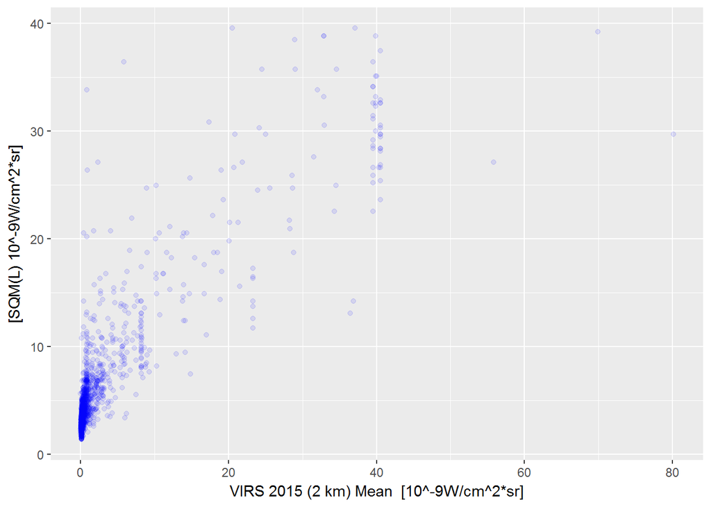

```r
ggplot(lp_data, aes(y=sqm, x=viirs_2015_2_mean)) + ylab(ylabel) + xlab("VIRS 2015 (2 km) Mean  [10^-9W/cm^2*sr]") + geom_point(color="blue", alpha=0.1)
```

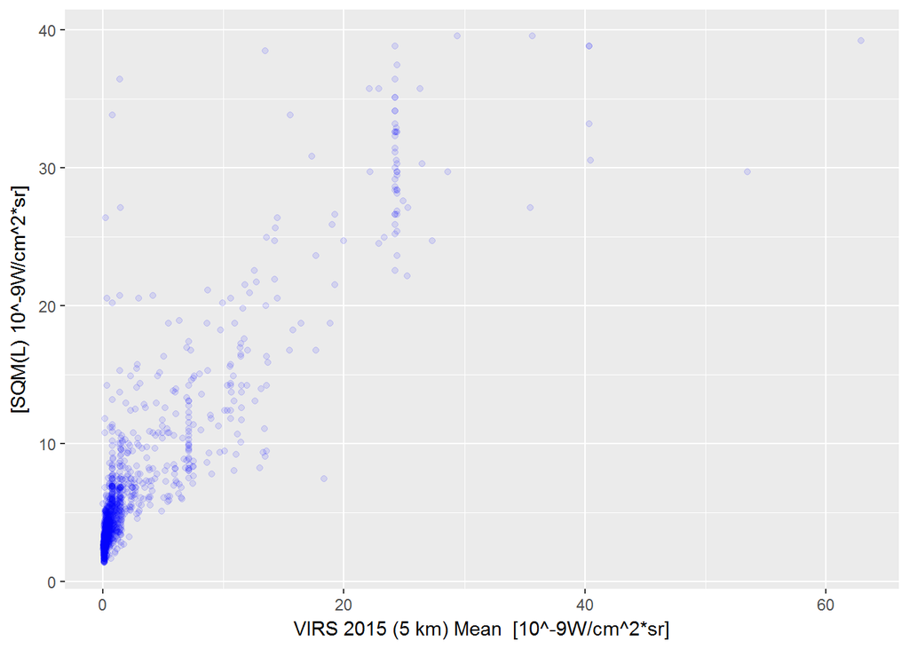

```r
ggplot(lp_data, aes(y=sqm, x=viirs_2015_5_mean)) + ylab(ylabel) + xlab("VIRS 2015 (5 km) Mean  [10^-9W/cm^2*sr]") + geom_point(color="blue", alpha=0.1)
```

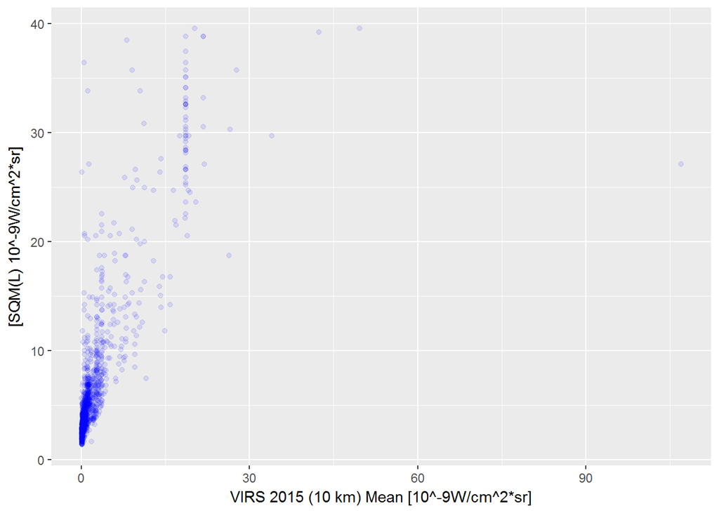

```r
ggplot(lp_data, aes(y=sqm, x=viirs_2015_10_mean)) + ylab(ylabel) + xlab("VIRS 2015 (10 km) Mean [10^-9W/cm^2*sr]") + geom_point(color="blue", alpha=0.1)
```

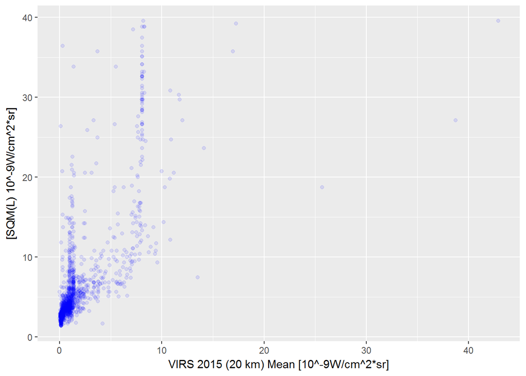

```r
ggplot(lp_data, aes(y=sqm, x=viirs_2015_20_mean)) + ylab(ylabel) + xlab("VIRS 2015 (20 km) Mean [10^-9W/cm^2*sr]") + geom_point(color="blue", alpha=0.1)
```

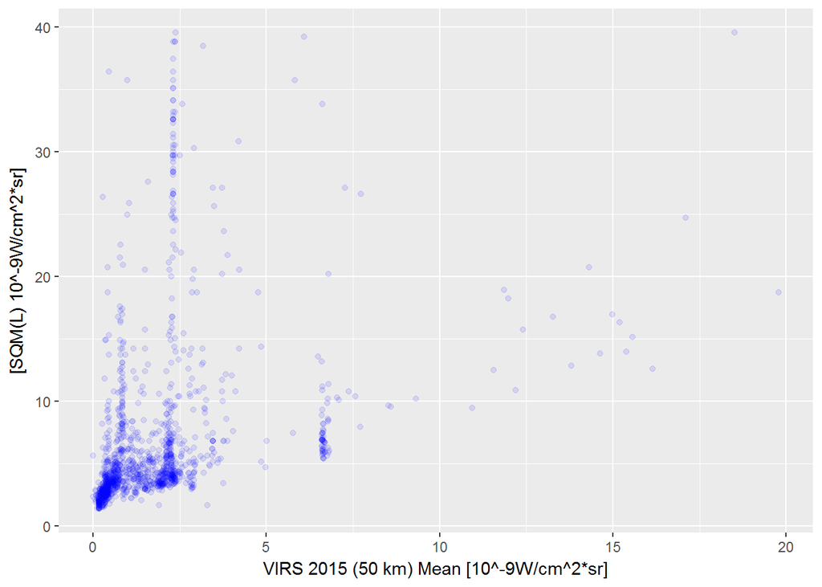

```r
ggplot(lp_data, aes(y=sqm, x=viirs_2015_50_mean)) + ylab(ylabel) + xlab("VIRS 2015 (50 km) Mean [10^-9W/cm^2*sr]") + geom_point(color="blue", alpha=0.1)
```

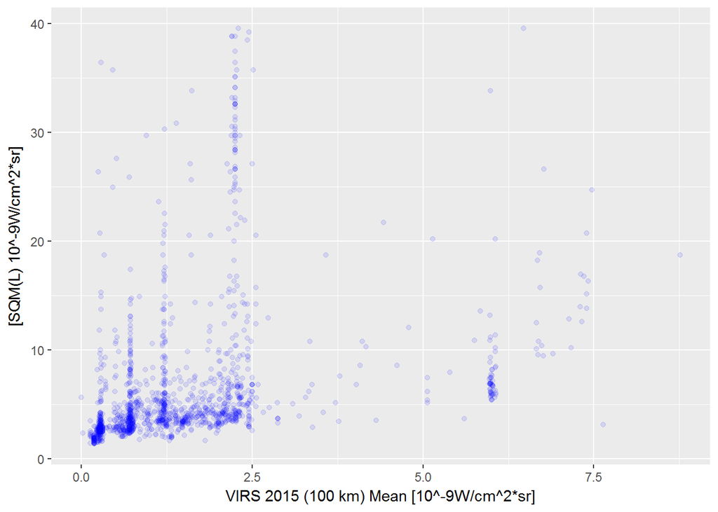

```r
ggplot(lp_data, aes(y=sqm, x=viirs_2015_100_mean)) + ylab(ylabel) + xlab("VIRS 2015 (100 km) Mean [10^-9W/cm^2*sr]") + geom_point(color="blue", alpha=0.1)
```

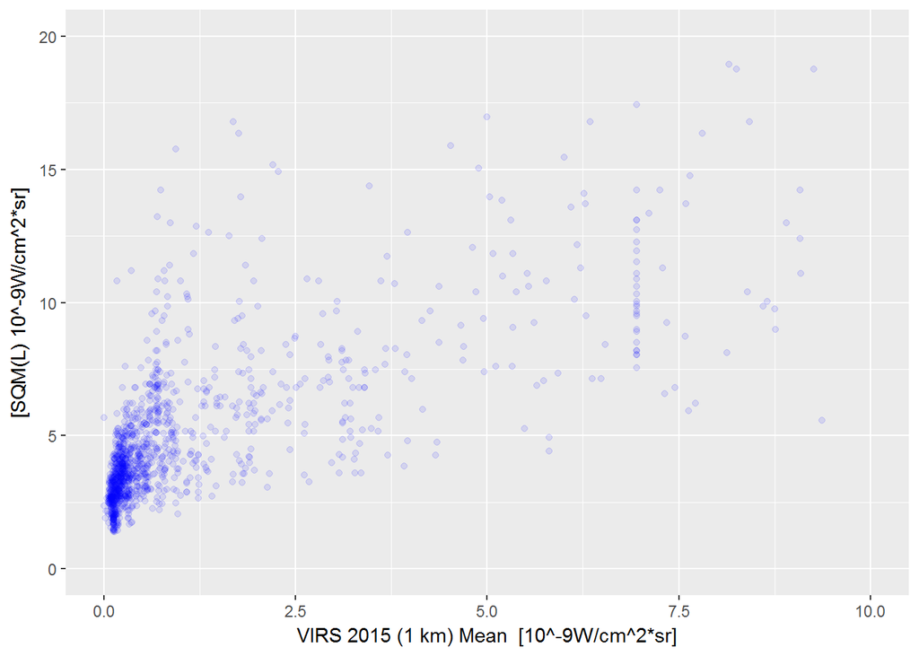

```r
## VIRS(sqm) for 1, 2, 5, 10, 20, 50, 100 [km]
ggplot(lp_data, aes(y=sqm, x=viirs_2015_1_mean)) + ylab(ylabel) + xlab("VIRS 2015 (1 km) Mean  [10^-9W/cm^2*sr]") + geom_point(color="blue", alpha=0.1) + xlim(0,10) + ylim(0,20)
```

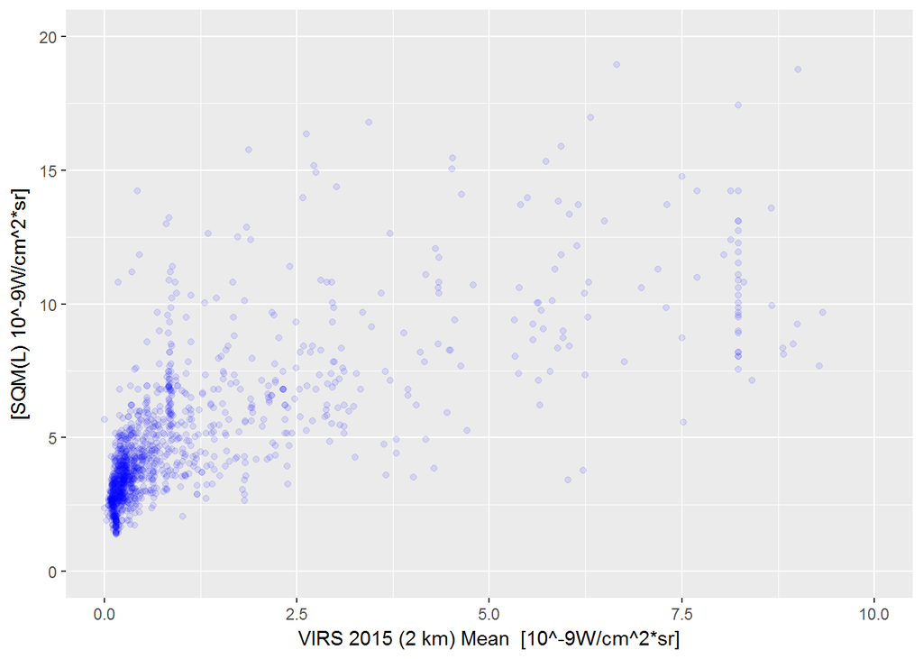

```r
ggplot(lp_data, aes(y=sqm, x=viirs_2015_2_mean)) + ylab(ylabel) + xlab("VIRS 2015 (2 km) Mean  [10^-9W/cm^2*sr]") + geom_point(color="blue", alpha=0.1) + xlim(0,10) + ylim(0,20)
```

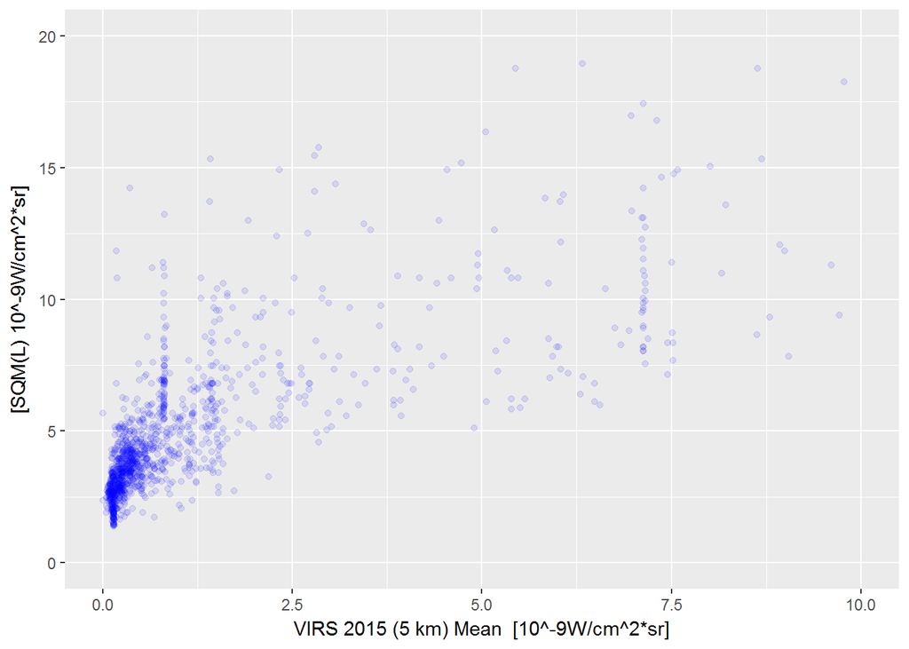

```r
ggplot(lp_data, aes(y=sqm, x=viirs_2015_5_mean)) + ylab(ylabel) + xlab("VIRS 2015 (5 km) Mean  [10^-9W/cm^2*sr]") + geom_point(color="blue", alpha=0.1) + xlim(0,10) +  ylim(0,20)
```

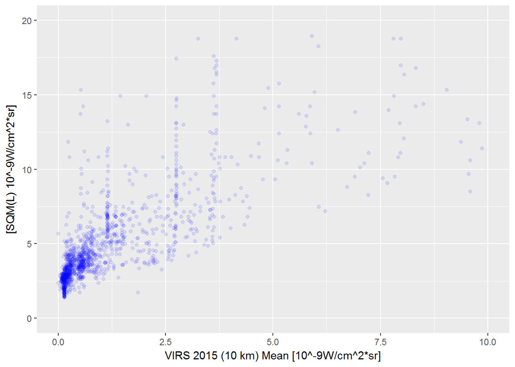

```r
ggplot(lp_data, aes(y=sqm, x=viirs_2015_10_mean)) + ylab(ylabel) + xlab("VIRS 2015 (10 km) Mean [10^-9W/cm^2*sr]") + geom_point(color="blue", alpha=0.1) + xlim(0,10) +  ylim(0,20)
```

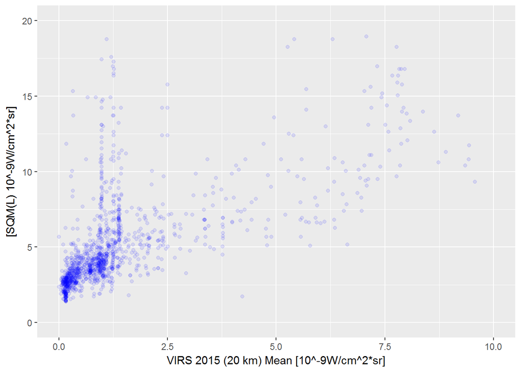

```r
ggplot(lp_data, aes(y=sqm, x=viirs_2015_20_mean)) + ylab(ylabel) + xlab("VIRS 2015 (20 km) Mean [10^-9W/cm^2*sr]") + geom_point(color="blue", alpha=0.1) + xlim(0,10) +  ylim(0,20)
```

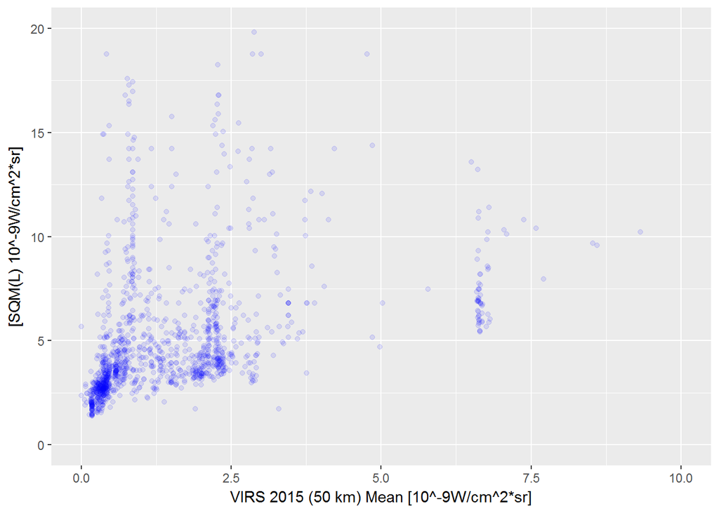

```r
ggplot(lp_data, aes(y=sqm, x=viirs_2015_50_mean)) + ylab(ylabel) + xlab("VIRS 2015 (50 km) Mean [10^-9W/cm^2*sr]") + geom_point(color="blue", alpha=0.1) + xlim(0,10) +  ylim(0,20)
```

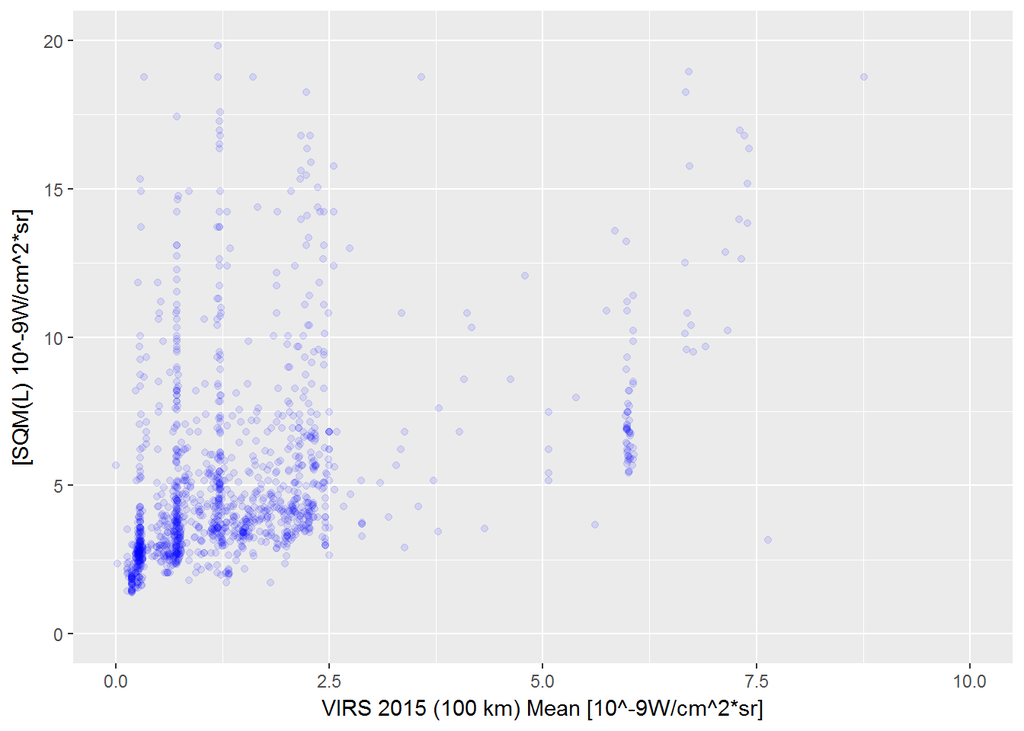

```r
ggplot(lp_data, aes(y=sqm, x=viirs_2015_100_mean)) + ylab(ylabel) + xlab("VIRS 2015 (100 km) Mean [10^-9W/cm^2*sr]") + geom_point(color="blue", alpha=0.1) + xlim(0,10) +  ylim(0,20)
```

# Correlation

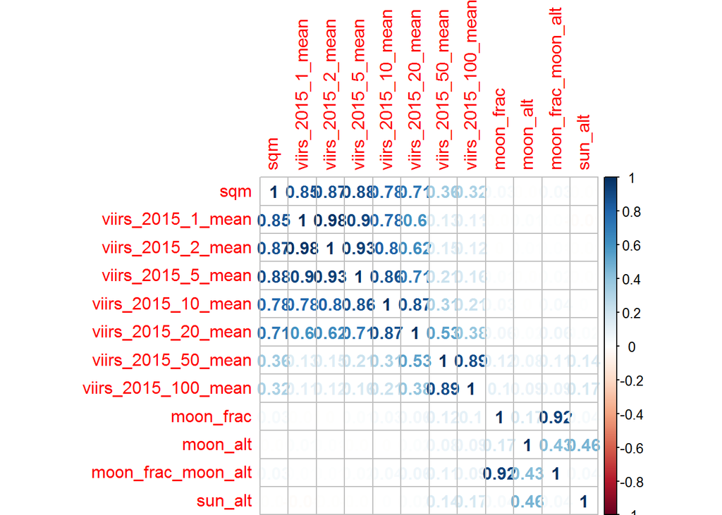

```r
corrplot(cor(lp_data[,grep("viirs_2015_.*_mean|sqm$|moon|sun", colnames(lp_data))]), method="number")
```

## Regression

```r
all_lm <- lm(sqm~viirs_2015_1_mean + viirs_2015_2_mean + viirs_2015_5_mean + viirs_2015_10_mean + viirs_2015_20_mean + viirs_2015_50_mean + viirs_2015_100_mean + moon_frac + moon_alt + moon_frac_moon_alt + sun_alt, data=lp_data)

summary(all_lm)
```

```
##
## Call:
## lm(formula = sqm ~ viirs_2015_1_mean + viirs_2015_2_mean + viirs_2015_5_mean +
##     viirs_2015_10_mean + viirs_2015_20_mean + viirs_2015_50_mean +
##     viirs_2015_100_mean + moon_frac + moon_alt + moon_frac_moon_alt +
##     sun_alt, data = lp_data)
##
## Residuals:
##      Min       1Q   Median       3Q      Max
## -26.8146  -0.8650  -0.3787   0.3194  29.8591
##
## Coefficients:
##                       Estimate Std. Error t value Pr(>|t|)
## (Intercept)          3.1216352  0.3298265   9.464  < 2e-16 ***
## viirs_2015_1_mean    0.2149244  0.0369082   5.823 7.10e-09 ***
## viirs_2015_2_mean    0.0890096  0.0495404   1.797   0.0726 .
## viirs_2015_5_mean    0.5554689  0.0377588  14.711  < 2e-16 ***
## viirs_2015_10_mean  -0.2649595  0.0375165  -7.062 2.53e-12 ***
## viirs_2015_20_mean   0.5078933  0.0585383   8.676  < 2e-16 ***
## viirs_2015_50_mean   0.1873310  0.0825196   2.270   0.0233 *
## viirs_2015_100_mean  0.4491030  0.1067391   4.207 2.74e-05 ***
## moon_frac            1.4962995  1.0926161   1.369   0.1711
## moon_alt             0.0003907  0.0059279   0.066   0.9475
## moon_frac_moon_alt  -0.0160432  0.0143243  -1.120   0.2629
## sun_alt             -0.0084270  0.0039801  -2.117   0.0344 *
## ---
## Signif. codes:  0 '***' 0.001 '**' 0.01 '*' 0.05 '.' 0.1 ' ' 1
##
## Residual standard error: 2.585 on 1452 degrees of freedom
## Multiple R-squared:  0.8472, Adjusted R-squared:  0.846
## F-statistic: 731.8 on 11 and 1452 DF,  p-value: < 2.2e-16
```

```r
lp_data = cv.lm(lp_data, all_lm, m=4, printit=FALSE)
```

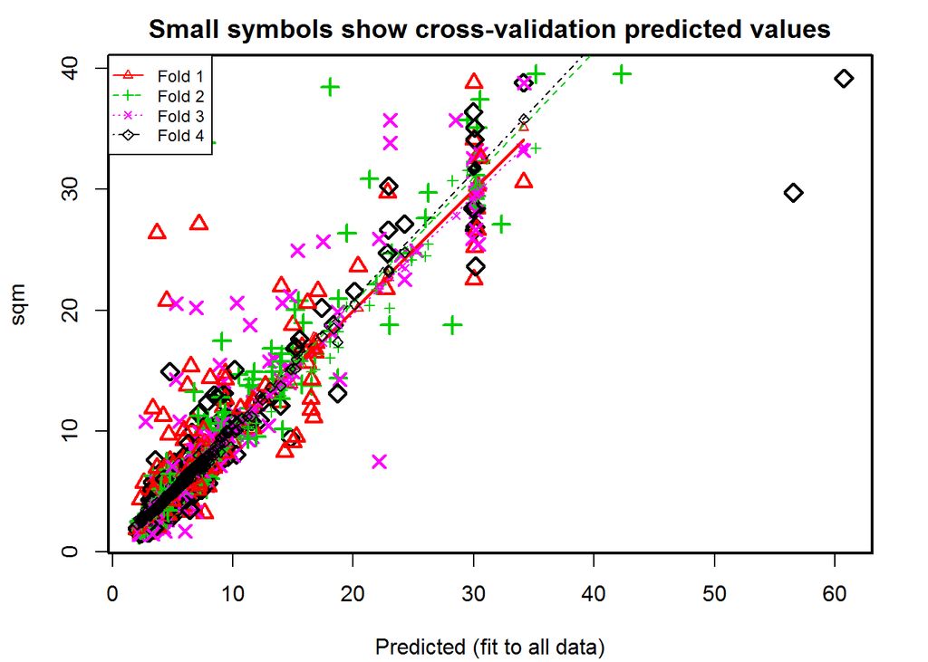

```r
sqrt(attr(lp_data, "ms"))
```

```
## [1] 2.815084
```

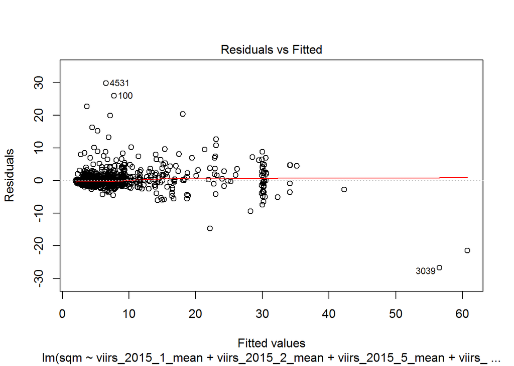

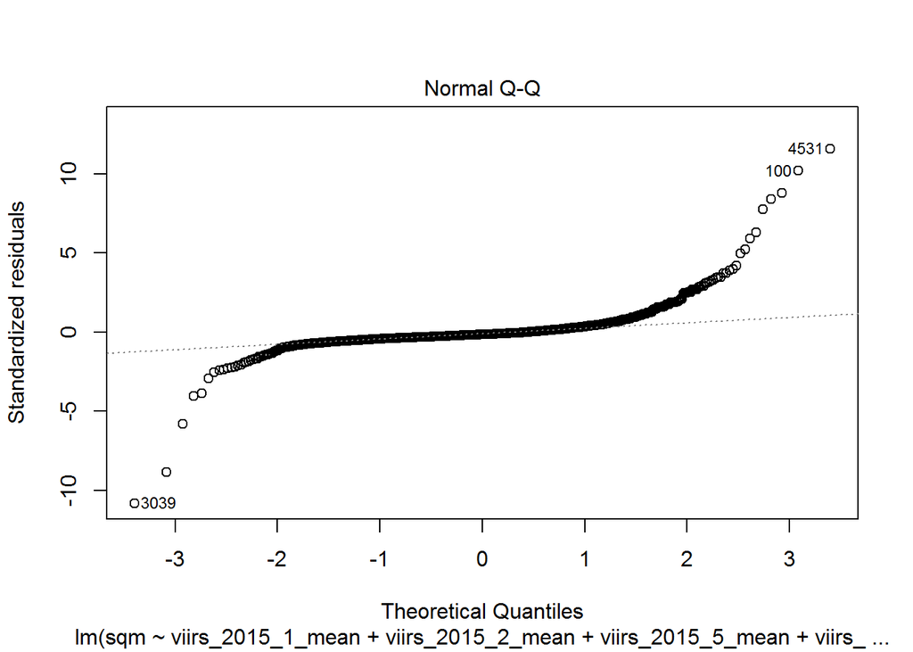

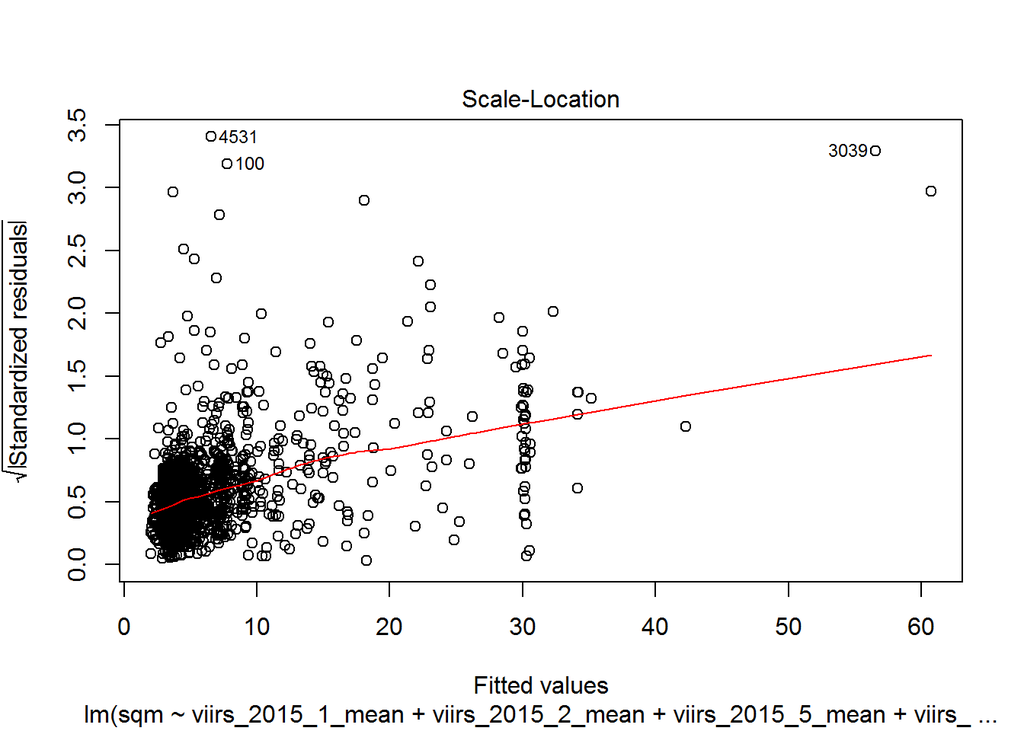

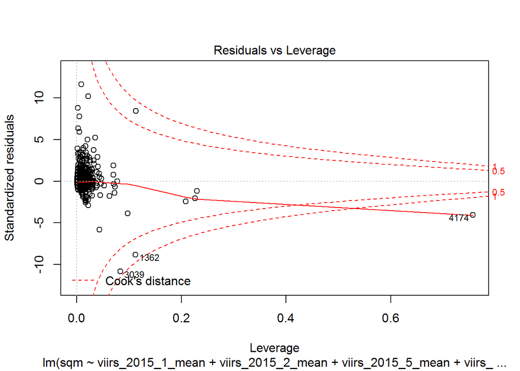

```r
plot(all_lm)
```

## Leaps

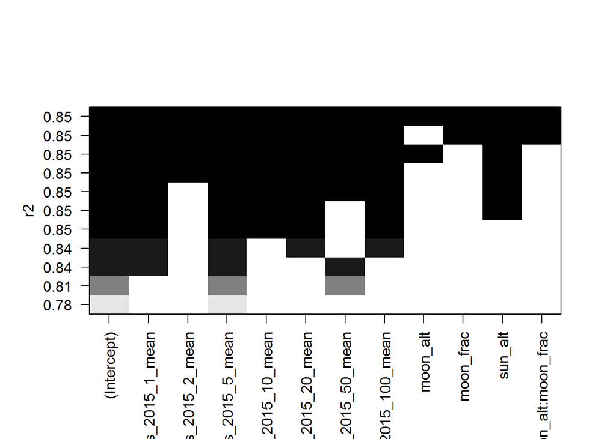

```r
library(leaps)
leaps<-regsubsets(sqm~viirs_2015_1_mean + viirs_2015_2_mean + viirs_2015_5_mean + viirs_2015_10_mean + viirs_2015_20_mean + viirs_2015_50_mean + viirs_2015_100_mean + moon_alt*moon_frac + sun_alt, data=lp_data, nbest=1,  nvmax=11)

# Plot a table of models showing variables in each model.
# models are ordered by the selection statistic.
plot(leaps,scale="r2")
```

## Regression variables subset

```r
subset_lm <- lm(sqm~viirs_2015_1_mean + viirs_2015_5_mean + viirs_2015_20_mean + viirs_2015_100_mean, data=lp_data)

summary(subset_lm)
```

```
##
## Call:
## lm(formula = sqm ~ viirs_2015_1_mean + viirs_2015_5_mean + viirs_2015_20_mean +
##     viirs_2015_100_mean, data = lp_data)
##
## Residuals:
##      Min       1Q   Median       3Q      Max
## -26.6878  -0.8812  -0.3974   0.3307  29.7895
##
## Coefficients:
##                     Estimate Std. Error t value Pr(>|t|)
## (Intercept)          2.70989    0.10301  26.307  < 2e-16 ***
## viirs_2015_1_mean    0.25321    0.01755  14.424  < 2e-16 ***
## viirs_2015_5_mean    0.50106    0.03005  16.672  < 2e-16 ***
## viirs_2015_20_mean   0.27705    0.03702   7.484 1.24e-13 ***
## viirs_2015_100_mean  0.71618    0.05295  13.527  < 2e-16 ***
## ---
## Signif. codes:  0 '***' 0.001 '**' 0.01 '*' 0.05 '.' 0.1 ' ' 1
##
## Residual standard error: 2.644 on 1459 degrees of freedom
## Multiple R-squared:  0.8394, Adjusted R-squared:  0.839
## F-statistic:  1907 on 4 and 1459 DF,  p-value: < 2.2e-16
```

```r
lp_data = cv.lm(lp_data, subset_lm, m=4, printit=FALSE)
```

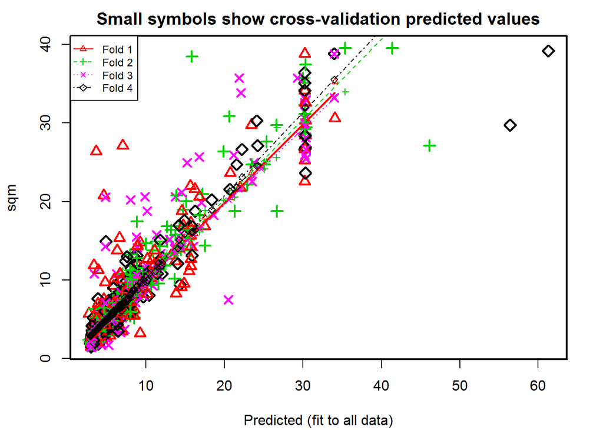

```r
sqrt(attr(lp_data, "ms"))
```

```
## [1] 2.765929
```

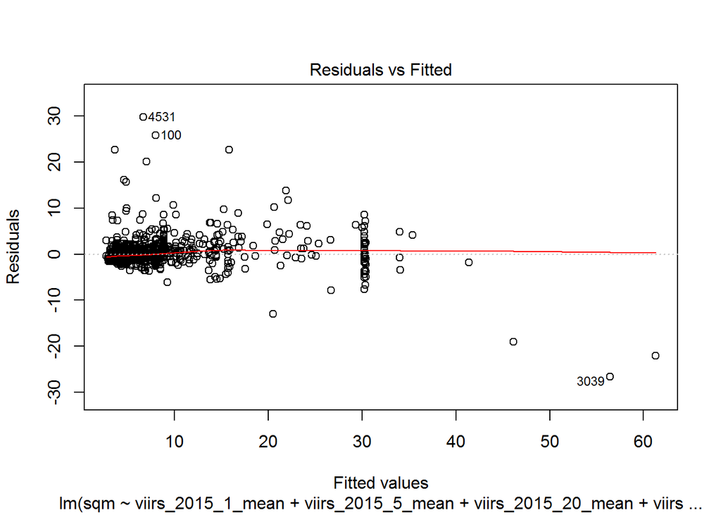

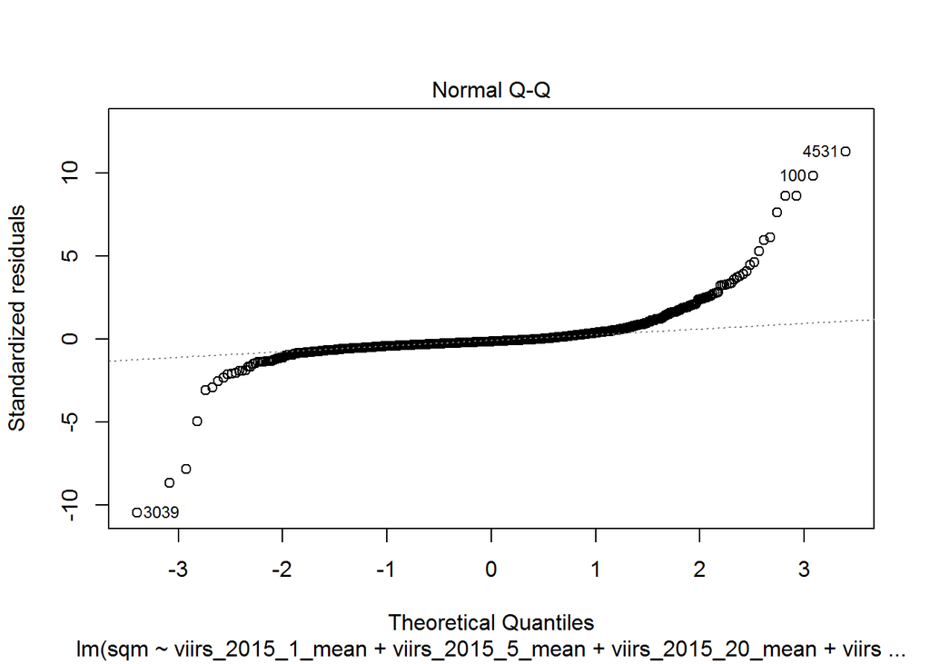

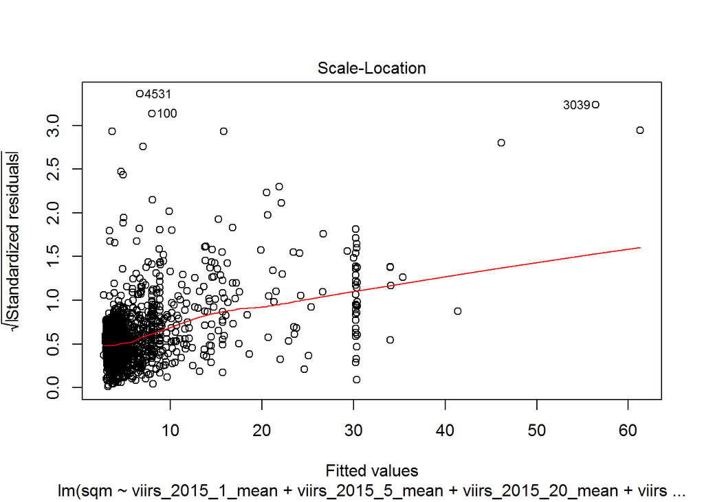

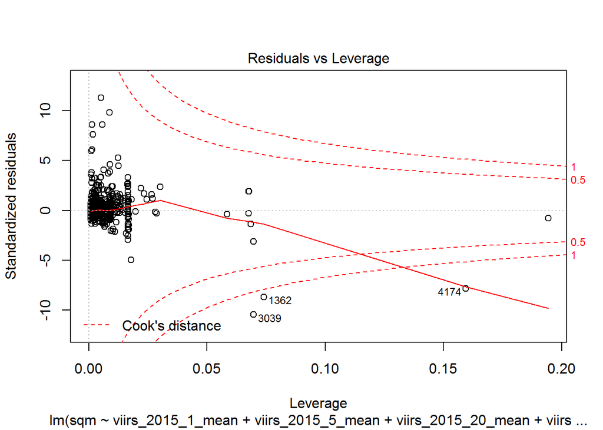

```r
plot(subset_lm)
```

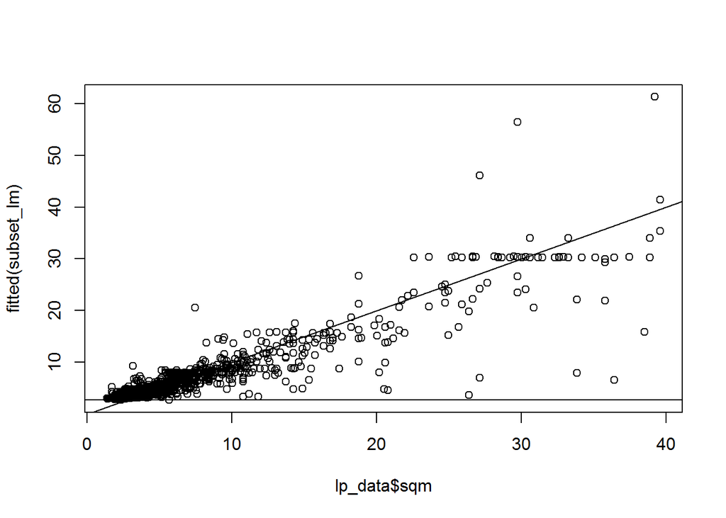

```
## numeric(0)
```

```r
plot(lp_data$sqm, fitted(subset_lm)) + abline(0, 1) + abline(subset_lm$coefficients[1], 0)
```

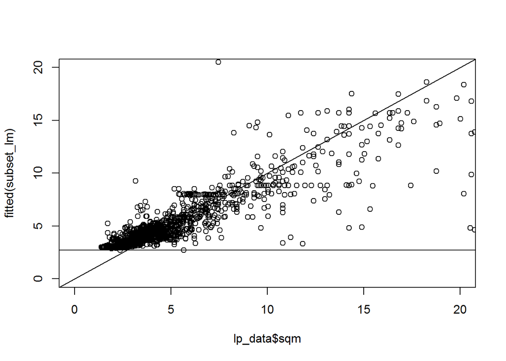

```
## numeric(0)
```

```r
plot(lp_data$sqm, fitted(subset_lm), xlim = c(0, 20), ylim = c(0, 20)) + abline(0, 1) + abline(subset_lm$coefficients[1], 0)
```

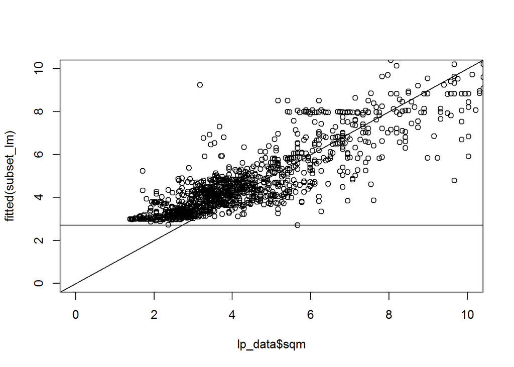

```
## numeric(0)
```

```r
plot(lp_data$sqm, fitted(subset_lm), xlim = c(0, 10), ylim = c(0, 10)) + abline(0, 1) + abline(subset_lm$coefficients[1], 0)
```